# Mid-term assignment

**Full Name:** Charalampos Sarakatsanis  
**ID Number:** 25267220  
**Subject:** Data Prog with Python (online)-2025/26 Autumn  
**Module Code:** STAT40800  
**Date:** October 28, 2025

## Question 1:

```python
#Reading-importing the dataset
import pandas as pd
my_path = "C:\\Users\\Chara\\Desktop\\MyDatasets\\car_sales_data.csv"
df = pd.read_csv(my_path)
```

```python
#looking at the shape of our dataset, to answer how many records are included.
df.shape[0]
```

```
50000
```

The code that we have ran, indicates that the dataset includes 50000 samples.

```python
print(df["Year of manufacture"].unique().shape[0])
df["Year of manufacture"].unique()
```

```
39
```

```
array([2002, 2016, 2014, 1988, 2006, 2018, 2010, 2015, 2012, 1992, 1990,
       2007, 1998, 1989, 2003, 1987, 1996, 2009, 2017, 2005, 2020, 2001,
       2008, 1995, 2000, 1994, 2004, 1997, 1993, 1991, 1999, 1985, 2021,
       2013, 1986, 1984, 2019, 2011, 2022])
```

The number of years of manufacture that are represented is 39 and the years are: 2002, 2016, 2014, 1988, 2006, 2018, 2010, 2015, 2012, 1992, 1990, 2007, 1998, 1989, 2003, 1987, 1996, 2009, 2017, 2005, 2020, 2001, 2008, 1995, 2000, 1994, 2004, 1997, 1993, 1991, 1999, 1985, 2021, 2013, 1986, 1984, 2019, 2011, 2022.

```python
#printing the "column-names"/"category-names"
df.columns
```

```
Index(['Manufacturer', 'Model', 'Engine size', 'Fuel type',
       'Year of manufacture', 'Mileage', 'Price'],
      dtype='object')
```

After running the latest code chunk, we have identified the following features are reported: `Manufacturer`, `Model`, `Engine size`, `Fuel type`, `Year of manufacture`, `Mileage` and `Price`.

## Question 2

- Manufacturers who appear most frequently

```python
#We print the number that each unique value appears in column/category "Manufacturer"
df["Manufacturer"].value_counts()
```

```
Manufacturer
Ford       14959
VW         14913
Toyota     12554
BMW         4965
Porsche     2609
Name: count, dtype: int64
```

The manufacturers who appear most frequently are: `Ford` (14959 times), with a similar frequency `VW` (14913 times) and `Toyota` (12554 times).

```python
- The proportions of different fuel types
```

```python
#Create a new data frame with the value counts
dfpropo = df["Fuel type"].value_counts().reset_index()
#We change the column names in order to make them clear
dfpropo.columns = ["Fuel type", "Proportion Percentage"]
#total number of cars
total = dfpropo["Proportion Percentage"].sum()
# Convert counts of each fuel type to percentage proportions
dfpropo["Proportion Percentage"] = (dfpropo["Proportion Percentage"]/total)*100
dfpropo
```

|  | Fuel type | Proportion Percentage |
| --- | --- | --- |
| 0 | Petrol | 50.976 |
| 1 | Diesel | 26.536 |
| 2 | Hybrid | 22.488 |

**The proportions of different fuel types are:**

| Fuel Type | Proportion Percentage |
| --- | --- |
| Petrol | 50.976% |
| Diesel | 26.536% |
| Hybrid | 22.488% |

## Question 3 Identify extremes

- The car with the highest sale price

```python
#We use idxmax to find the row number with the maximum car price and loc to print that row
df.loc[df["Price"].idxmax()]
```

```
Manufacturer              BMW
Model                      M5
Engine size               5.0
Fuel type              Petrol
Year of manufacture      2022
Mileage                  4590
Price                  168081
Name: 22786, dtype: object
```

The car with the highest `Price` at 168081 is **BMW M5**.

- Car with the lowest mileage

```python
#We use idxmin to find the row number with the lowest Mileage and loc to print that row
df.loc[df["Mileage"].idxmin()]
```

```
Manufacturer               VW
Model                    Golf
Engine size               1.8
Fuel type              Diesel
Year of manufacture      2022
Mileage                   630
Price                   45601
Name: 30697, dtype: object
```

- Car with the largest engine size

```python
#because the number 5.0 was shown a lot of times in the dataset, lets check if there are more than one car models with engine size equal to 5.
df[df["Engine size"] == df["Engine size"].max()].drop_duplicates(subset=["Model"])
```

|  | Manufacturer | Model | Engine size | Fuel type | Year of manufacture | Mileage | Price |
| --- | --- | --- | --- | --- | --- | --- | --- |
| 236 | BMW | M5 | 5.0 | Petrol | 2016 | 42059 | 91415 |

The car with the largest `Engine size` at 5 is **BMW M5**, there are no other car models with that engine size.

## Question 4 Create a numerical summary of numerical features

```python
#We select from the dataset, the objects that include numbers
summary = df.select_dtypes(include='number')
print("An example of what the first rows of the numerical parts of the dataset looks like:\n")
print(summary.head(),"\n\n")
print("Data types, column names and count of non null values of the numerical part of the dataset:\n")
print(summary.info(),"\n\n")
print("Simple statistical summary of the numerical part of the dataset\n(Count, Mean, Standard Deviation, Min, Max, and the 25%, 50%, 75% percentiles):\n")
print(summary.describe(),"\n")
```

```
An example of what the first rows of the numerical parts of the dataset looks like:

   Engine size  Year of manufacture  Mileage  Price
0          1.0                 2002   127300   3074
1          4.0                 2016    57850  49704
2          1.6                 2014    39190  24072
3          1.8                 1988   210814   1705
4          1.0                 2006   127869   4101


Data types, column names and count of non null values of the numerical part of the dataset:

<class 'pandas.core.frame.DataFrame'>
RangeIndex: 50000 entries, 0 to 49999
Data columns (total 4 columns):
 #   Column               Non-Null Count  Dtype
---  ------               --------------  -----
 0   Engine size          50000 non-null  float64
 1   Year of manufacture  50000 non-null  int64
 2   Mileage              50000 non-null  int64
 3   Price                50000 non-null  int64
dtypes: float64(1), int64(3)
memory usage: 1.5 MB
None


Simple statistical summary of the numerical part of the dataset
(Count, Mean, Standard Deviation, Min, Max, and the 25%, 50%, 75% percentiles):

        Engine size  Year of manufacture        Mileage          Price
count  50000.000000         50000.000000   50000.000000   50000.000000
mean       1.773058          2004.209440  112497.320700   13828.903160
std        0.734108             9.645965   71632.515602   16416.681336
min        1.000000          1984.000000     630.000000      76.000000
25%        1.400000          1996.000000   54352.250000    3060.750000
50%        1.600000          2004.000000  100987.500000    7971.500000
75%        2.000000          2012.000000  158601.000000   19026.500000
max        5.000000          2022.000000  453537.000000  168081.000000
```

## Question 5 Create visual summaries for price, mileage, and engine size

- summary for price

```
[Text(0.5, 1.0, 'Car Price-Number of Cars | KDE curve histogram'),
```

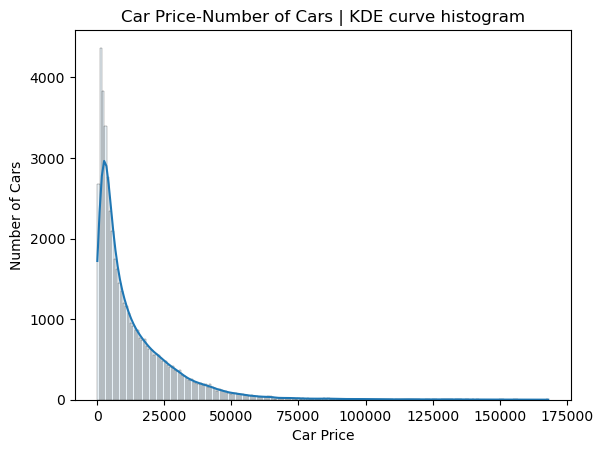

```python
#We will use seaborn to create a faint histogram, with a less transparent
#kernel density estimation (KDE) curve, that will continuously visualize data,
#based on the actual number of cars and engine size and not the probability density for the count.
import seaborn as sns
myplot = sns.histplot(df["Price"], kde=True, stat="count", alpha=0.1)
myplot.set(title = "Car Price-Number of Cars | KDE curve histogram", ylabel="Number of Cars", xlabel="Car Price")
```

- summary for Mileage

```
[Text(0.5, 1.0, 'Mileage-Number of Cars | KDE curve, histogram'),
```

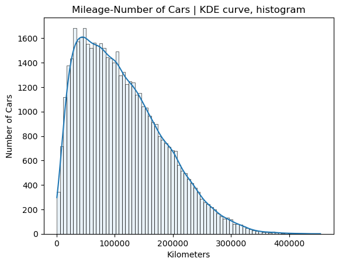

```python
#We use seaborn to create a faint histogram, with a less transparent
#kernel density estimation (KDE) curve, that will continuously visualize data,
#based on the actual number of cars and engine size and not the probability density for the count.
myplot = sns.histplot(df["Mileage"], kde=True, stat="count", alpha=0.1)
myplot.set(title = "Mileage-Number of Cars | KDE curve, histogram", ylabel="Number of Cars", xlabel="Kilometers")
```

- summary for engine size

```
[Text(0.5, 1.0, 'Engine size-Number of Cars | KDE curve, histogram'),
```

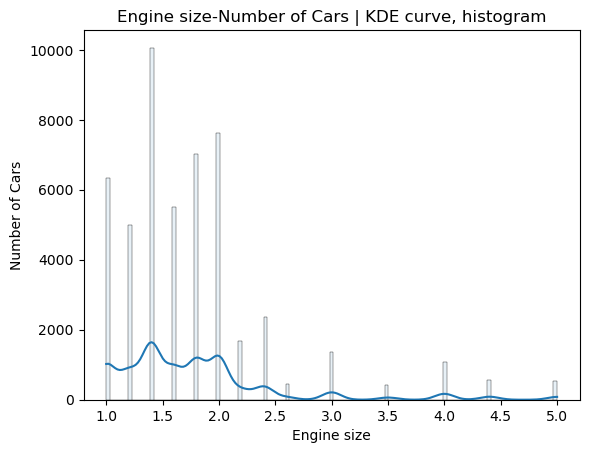

```python
#We use seaborn to create a faint histogram, with a less transparent
#kernel density estimation (KDE) curve, that will continuously visualize data,
#based on the actual number of cars and engine size and not the probability density for the count.
myplot = sns.histplot(df["Engine size"], kde=True, stat="count", alpha=0.1)
myplot.set(title = "Engine size-Number of Cars | KDE curve, histogram", ylabel="Number of Cars", xlabel="Engine size")
```

## Question 6 Produce a scatter plot of price vs mileage, coloured by fuel type.

```
[Text(0.5, 1.0, 'Car Price vs Mileage, by fuel type'),
```

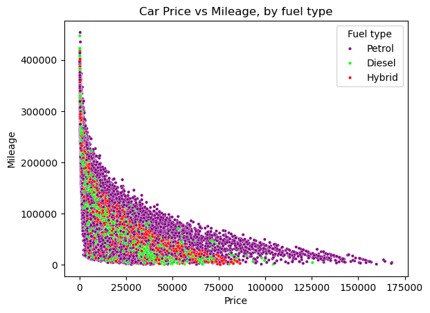

```python
#Creating a seaborn scatterplot.
#X-axis displayes the Price
#Y-axis displayes the Mileage
#The different colors tell us the fuel type: purple for 'Petrol', lime for 'Diesel', red 'Hybrid'.
myplot=sns.scatterplot(
    data=df,
    x="Price",
    y="Mileage",
    hue="Fuel type", #legend based on the fuel type
    palette={'Petrol': 'Purple', 'Diesel': 'lime', 'Hybrid': 'red'}, #specifying the color for each case of fuel type.
    s=10
)
myplot.set(title = "Car Price vs Mileage, by fuel type", ylabel="Mileage", xlabel="Price")
```

## Question 7 Compute price per kilometre

```python
#We divide "Price" with "Mileage" for every column in order to obtain price per kilometer.
#We will add this to our data frame since it is useful information.
df["Price per Kilometer"] = df["Price"]/df["Mileage"]
```

## Question 8 Plot car price vs year of manufacture, colouring points by manufacturer

```
[Text(0.5, 1.0, 'Car Price vs Year of Manufacture, by Manufacturer'),
```

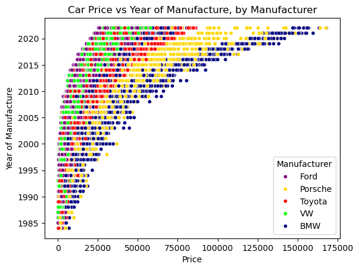

```python
#Creating a seaborn scatterplot.
#X-axis displayes the Price
#Y-axis displayes the Year of manufacture
#The different colors tell us the Manufacturer: purple for 'Ford', gold for 'Porsche', red for 'Toyota', lime for 'VW' and blue for 'BMW'.
myplot=sns.scatterplot(
    data=df,
    x="Price",
    y="Year of manufacture",
    hue="Manufacturer", #legend based on fuel type
    palette={'Ford': 'Purple', 'VW': 'lime', 'Toyota': 'red', 'BMW': 'navy', 'Porsche': 'gold'}, #specifying the color for each case of "Manufacturer".
    s=20,
)
myplot.set(title = "Car Price vs Year of Manufacture, by Manufacturer", ylabel="Year of Manufacture", xlabel="Price")
```

## Question 9 Compare Toyota and BMW.

We will first visualize some data, in order to compare the two Manufacturers.

```
[Text(0.5, 1.0, 'Car Price vs Year of Manufacture, by Manufacturer'),
```

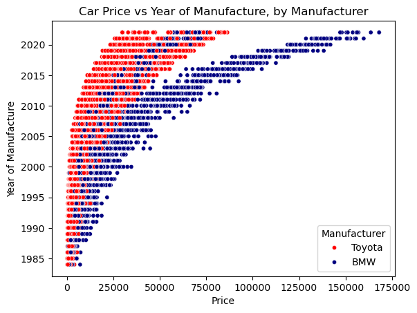

```python
#Create a data frame only with the manufacturers "BMW" and "Toyota"
comparison = df[(df["Manufacturer"] == "BMW") | (df["Manufacturer"] == "Toyota")]
#Creating a seaborn scatterplot to compare the two manufacturers.
#X-axis displays the Price
#Y-axis displays the Year of manufacture
#The different colors tell us the Manufacturer: Red for 'Toyota' and blue for 'BMW'.
myplot=sns.scatterplot(
    data=comparison,
    x="Price",
    y="Year of manufacture",
    hue="Manufacturer", #legend based on fuel type
    palette={'Toyota': 'red', 'BMW': 'navy'}, #specifying the color for each case of "Manufacturer".
    s=20,
)
myplot.set(title = "Car Price vs Year of Manufacture, by Manufacturer", ylabel="Year of Manufacture", xlabel="Price")
```

From that scatter plot, it is clear that BMW even though the prices may vary, `BMW` sell the most expensive cars. The difference between prices between the two manufacturers becomes more distinguisable as the years pass by, with `BMW` having a higher price increasing rate than `Toyota`. Both manufacturers produce cars all the years and steadily increase the number of cars as the years pass by, with `Toyota` slightly producing more cars by 2020.

```
[Text(0.5, 1.0, 'Engine size vs Mileage, by Manufacturer'),
```

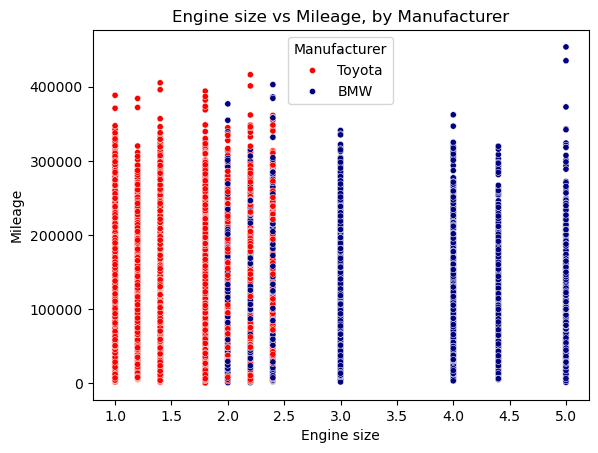

```python
#Creating a seaborn scatterplot to compare the two manufacturers.
#X-axis displayes the Engine size
#Y-axis displayes the Mileage
#The different colors tell us the Manufacturer: Red for 'Toyota' and blue for 'BMW'.
myplot=sns.scatterplot(
    data=comparison,
    x="Engine size",
    y="Mileage",
    hue="Manufacturer", #legend based on fuel type
    palette={'Toyota': 'red', 'BMW': 'navy'}, #specifying the color for each case of "Manufacturer".
    s=20,
)
myplot.set(title = "Engine size vs Mileage, by Manufacturer", ylabel="Mileage", xlabel="Engine size")
```

The cars from both `manufacturers` have similar mileage. Great differences can be spotted when it comes to engine size. `Toyota` produces smaller engines with size from 1 to approximately 2.5. On the other hand, `BMW` produces engines from size 2 to size 5. Both companies produce engines of size from 2 to a little less than 2.5.

```
[Text(0.5, 1.0, 'Fuel type vs count of cars, by Manufacturer'),
```

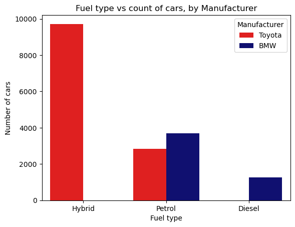

```python
myplot=sns.countplot(
    data=comparison,
    x="Fuel type",
    hue="Manufacturer",
    palette={'Toyota': 'red', 'BMW': 'navy'}
)
myplot.set(title = "Fuel type vs count of cars, by Manufacturer", ylabel="Number of cars", xlabel="Fuel type")
```

**Hybrid**

- `Toyota's` hybrid cars number almost reaches 10000 which is 1/5 of our whole dataset and what `Toyota` mostly creates.
- `BMW` does not make any hybrid cars.

**Petrol**

- `Toyota` creates around 3000 Petrol engine cars, approximately 1000 less than what `BMW` makes
- `BMW` sold close to 4000 petrol fueled cars and this is the most popular engine type `BMW` posses.

```python
BMW = df[df["Manufacturer"]=="BMW"]
Toyota = df[df["Manufacturer"]=="Toyota"]
print("BMW total sales =", BMW["Price"].sum())
print("Toyota total sales =", Toyota["Price"].sum())
print("Total cars sold by BMW:", BMW.shape[0])
print("Total cars sold by Toyota:", Toyota.shape[0])
print("Mean of BMW's earnings per car:", BMW["Price"].sum()/BMW.shape[0])
print("Mean of Toyota's earnings per car:", Toyota["Price"].sum()/Toyota.shape[0])
```

```
BMW total sales = 121292265
Toyota total sales = 180028908
Total cars sold by BMW: 4965
Total cars sold by Toyota: 12554
Mean of BMW's earnings per car: 24429.459214501512
Mean of Toyota's earnings per car: 14340.36227497212
```

**In terms of sales:**

| Manufacturer | Cars Sold | Total Revenue | Average Revenue per Car |
| --- | --- | --- | --- |
| **Toyota** | 12,554 | 180,028,908 | 14,340 |
| **BMW** | 4,965 | 121,292,265 | 24,430 |